## Setup

### Load packages

```r
#Load Packages
library(ggplot2)
library(dplyr)
library(statsr)
library(BAS)
library(MASS)
library(tidyverse)
library(broom)
```

### Load data

```r
#Load Data
load("movies.Rdata")
```

## Part 1: Data

The movies dataset is made up of 651 randomly sampled movies produced and released before 2016 from Rotten Tomatoes and IMBD. Since **random sampling** was used to collect the data, the results can be generalised to movies produced and released between 1970 and 2016.

However, only correlational statements and conclusions can be made as this is an **observational study** and the data collection involved **no random assignment** to perform an experiment. Hence, no causal relationships can be established from this dataset.

The data in the dataset comes from Rotten Tomatoes and IMDB, both of which are sites that volunteers contribute to. It’s possible that only people with strong opinions about a movie and movie enthusiasts contribute to the two sites. Hence, the data itself might include convenience and response biases that makes the data different from that of the actual population.

## Part 2: Data manipulation

The specific modeling task for this project is to develop a Bayesian regression model to predict audience_score from a given list of explanatory variables - feature_film, drama, runtime, mpaa_rating_R, thtr_rel_year, oscar_season, summer_season, imdb_rating, imdb_num_votes, critics_score, best_pic_nom, best_pic_win, best_actor_win, best_actress_win, best_dir_win and top200_box.

Of these variables, we are going to create the new variables required - feature_film, drama, mpaa_rating_R, oscar_season and summer_season using the mutate function. Then we will use the select function to add the other required variables into our new dataframe and get rid of the unimportant variables suchc as actor1-actor5 etc.

```r
#Create new variables and extract re unimportant variables
moviedata <- movies %>% mutate(
  feature_film = ifelse(title_type == "Feature Film", "yes", "no"),
  drama = ifelse(genre == "Drama", "yes", "no"),
  mpaa_rating_R = ifelse(mpaa_rating == "R", "yes", "no"),
  oscar_season = ifelse(thtr_rel_month %in% c(10, 11, 12), "yes", "no"),
  summer_season = ifelse(thtr_rel_month %in% c(5, 6, 7, 8),"yes", "no")) %>%
  dplyr::select(audience_score, feature_film, drama, runtime,  mpaa_rating_R, thtr_rel_year, oscar_season, summer_season, imdb_rating, imdb_num_votes, critics_score, best_pic_nom, best_pic_win, best_actor_win, best_actress_win, best_dir_win, top200_box)

moviedata$feature_film <- as.factor(moviedata$feature_film)
moviedata$drama <- as.factor(moviedata$drama)
moviedata$mpaa_rating_R <- as.factor(moviedata$mpaa_rating_R)
moviedata$oscar_season <- as.factor(moviedata$oscar_season)
moviedata$summer_season <- as.factor(moviedata$summer_season)

str(moviedata)
```

```
## Classes 'tbl_df', 'tbl' and 'data.frame':    651 obs. of  17 variables:
##  $ audience_score  : num  73 81 91 76 27 86 76 47 89 66 ...
##  $ feature_film    : Factor w/ 2 levels "no","yes": 2 2 2 2 2 1 2 2 1 2 ...
##  $ drama           : Factor w/ 2 levels "no","yes": 2 2 1 2 1 1 2 2 1 2 ...
##  $ runtime         : num  80 101 84 139 90 78 142 93 88 119 ...
##  $ mpaa_rating_R   : Factor w/ 2 levels "no","yes": 2 1 2 1 2 1 1 2 1 1 ...
##  $ thtr_rel_year   : num  2013 2001 1996 1993 2004 ...
##  $ oscar_season    : Factor w/ 2 levels "no","yes": 1 1 1 2 1 1 1 2 1 1 ...
##  $ summer_season   : Factor w/ 2 levels "no","yes": 1 1 2 1 1 1 1 1 1 1 ...
##  $ imdb_rating     : num  5.5 7.3 7.6 7.2 5.1 7.8 7.2 5.5 7.5 6.6 ...
##  $ imdb_num_votes  : int  899 12285 22381 35096 2386 333 5016 2272 880 12496 ...
##  $ critics_score   : num  45 96 91 80 33 91 57 17 90 83 ...
##  $ best_pic_nom    : Factor w/ 2 levels "no","yes": 1 1 1 1 1 1 1 1 1 1 ...
##  $ best_pic_win    : Factor w/ 2 levels "no","yes": 1 1 1 1 1 1 1 1 1 1 ...
##  $ best_actor_win  : Factor w/ 2 levels "no","yes": 1 1 1 2 1 1 1 2 1 1 ...
##  $ best_actress_win: Factor w/ 2 levels "no","yes": 1 1 1 1 1 1 1 1 1 1 ...
##  $ best_dir_win    : Factor w/ 2 levels "no","yes": 1 1 1 2 1 1 1 1 1 1 ...
##  $ top200_box      : Factor w/ 2 levels "no","yes": 1 1 1 1 1 1 1 1 1 1 ...
```

## Part 3: Exploratory data analysis

Let’s now look at a summary of the data.

```r
#Summary of the data
summary(moviedata)
```

```
##  audience_score  feature_film drama        runtime      mpaa_rating_R
##  Min.   :11.00   no : 60      no :346   Min.   : 39.0   no :322
##  1st Qu.:46.00   yes:591      yes:305   1st Qu.: 92.0   yes:329
##  Median :65.00                          Median :103.0
##  Mean   :62.36                          Mean   :105.8
##  3rd Qu.:80.00                          3rd Qu.:115.8
##  Max.   :97.00                          Max.   :267.0
##                                         NA's   :1
##  thtr_rel_year  oscar_season summer_season  imdb_rating
##  Min.   :1970   no :460      no :443       Min.   :1.900
##  1st Qu.:1990   yes:191      yes:208       1st Qu.:5.900
##  Median :2000                              Median :6.600
##  Mean   :1998                              Mean   :6.493
##  3rd Qu.:2007                              3rd Qu.:7.300
##  Max.   :2014                              Max.   :9.000
##
##  imdb_num_votes   critics_score    best_pic_nom best_pic_win
##  Min.   :   180   Min.   :  1.00   no :629      no :644
##  1st Qu.:  4546   1st Qu.: 33.00   yes: 22      yes:  7
##  Median : 15116   Median : 61.00
##  Mean   : 57533   Mean   : 57.69
##  3rd Qu.: 58301   3rd Qu.: 83.00
##  Max.   :893008   Max.   :100.00
##
##  best_actor_win best_actress_win best_dir_win top200_box
##  no :558        no :579          no :608      no :636
##  yes: 93        yes: 72          yes: 43      yes: 15
##
##
##
##
##
```

Looking through the data, we see that the runtime has 1 NA value. We’ll get rid of this observation since Bayesian regression makes use of the complete data.

```r
#Get rid of the observations with NA
moviedata <- moviedata %>% na.omit()
```

We are ultimately interested in predicting the audience reception of a movie. Hence our response variable would be audience_score. Let’s look at a histogram of this variable to get a sense of the distribution shape.

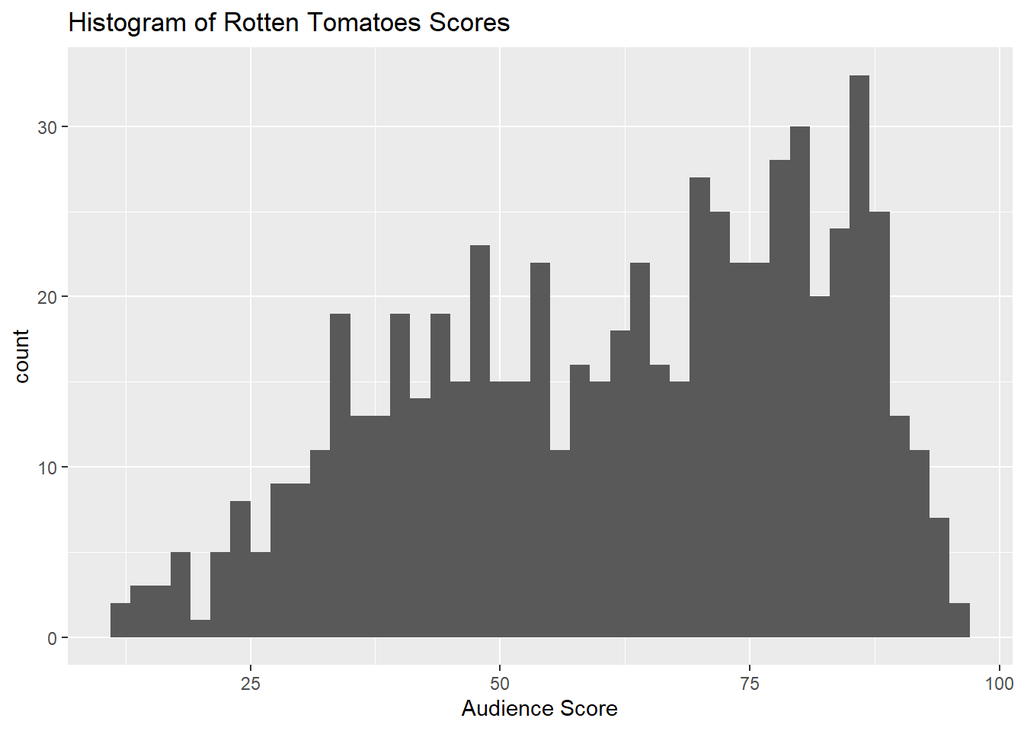

```r
#Histogram of Rotten Tomatoes Audience Scores
ggplot(moviedata, aes(x = audience_score)) + geom_histogram(binwidth = 2) +
  labs(title ="Histogram of Rotten Tomatoes Scores" ,x = "Audience Score")
```

The plot shows left skewness, with the bulk of the responses in the right section of the plot.

Let us now look at the boxplots of audience_score for different categories of the newly created variables.

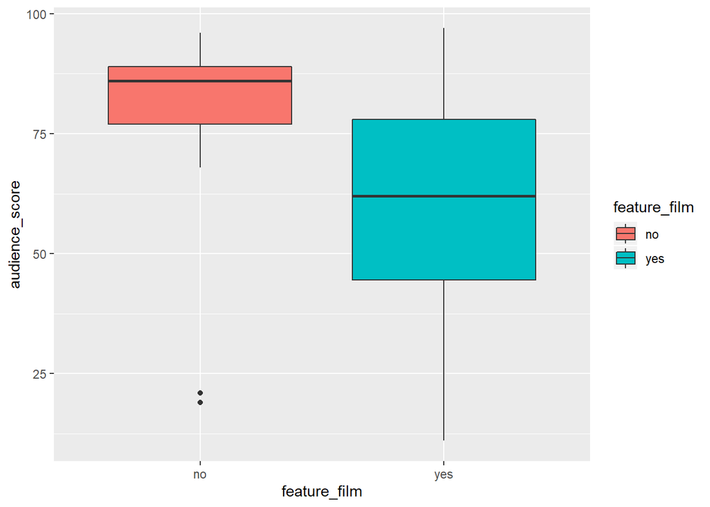

```r
#Feature film Vs Audience Score
ggplot(moviedata, aes(x = feature_film, y=audience_score, fill=feature_film))+ geom_boxplot()
```

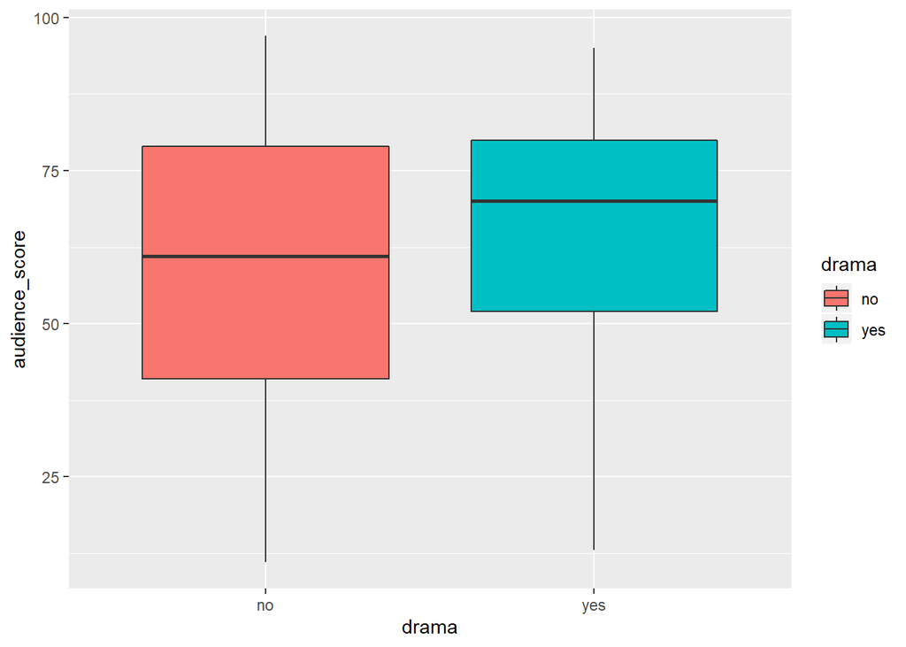

```r
#Drama Vs Audience Score
ggplot(moviedata, aes(x = drama, y=audience_score, fill=drama))+ geom_boxplot()
```

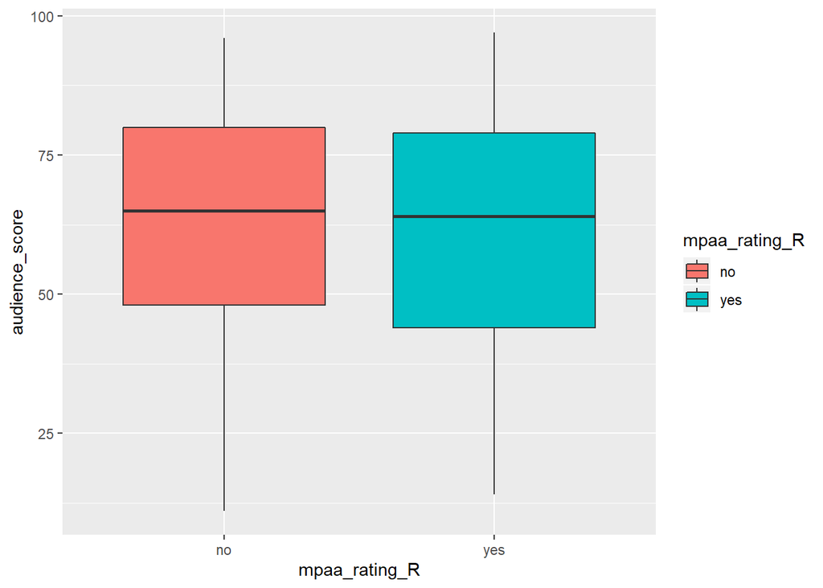

```r
#R Rating Vs Audience Score
ggplot(moviedata, aes(x = mpaa_rating_R, y=audience_score, fill=mpaa_rating_R))+ geom_boxplot()
```

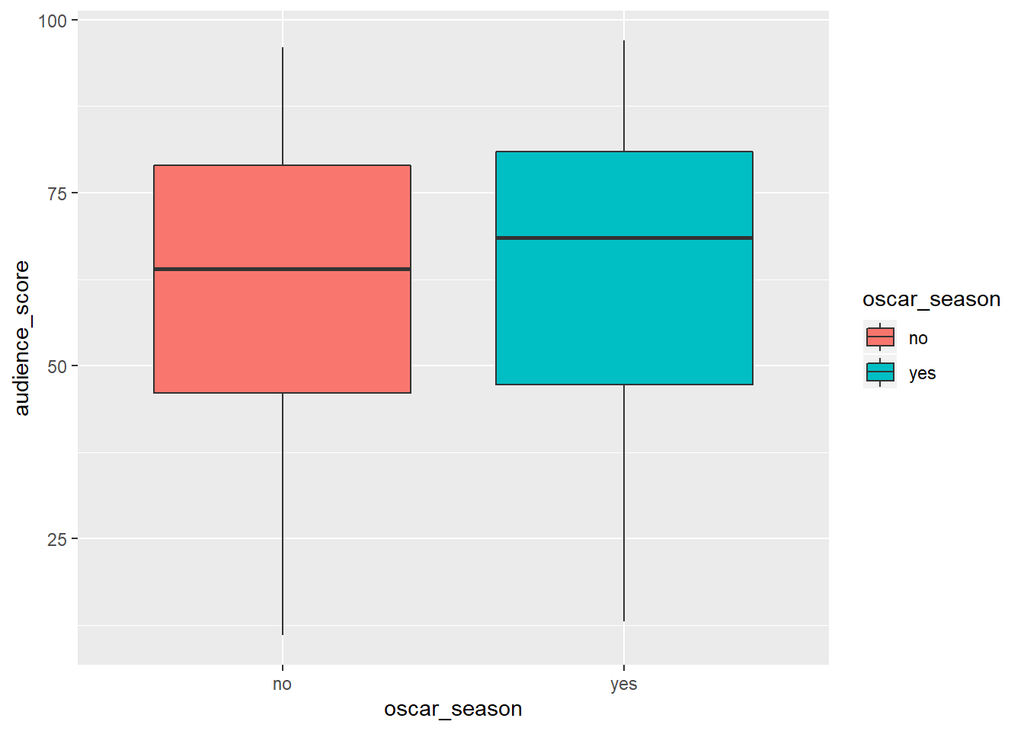

```r
#Released in Oscar Season Vs Audience Score
ggplot(moviedata, aes(x = oscar_season, y=audience_score, fill=oscar_season))+ geom_boxplot()
```

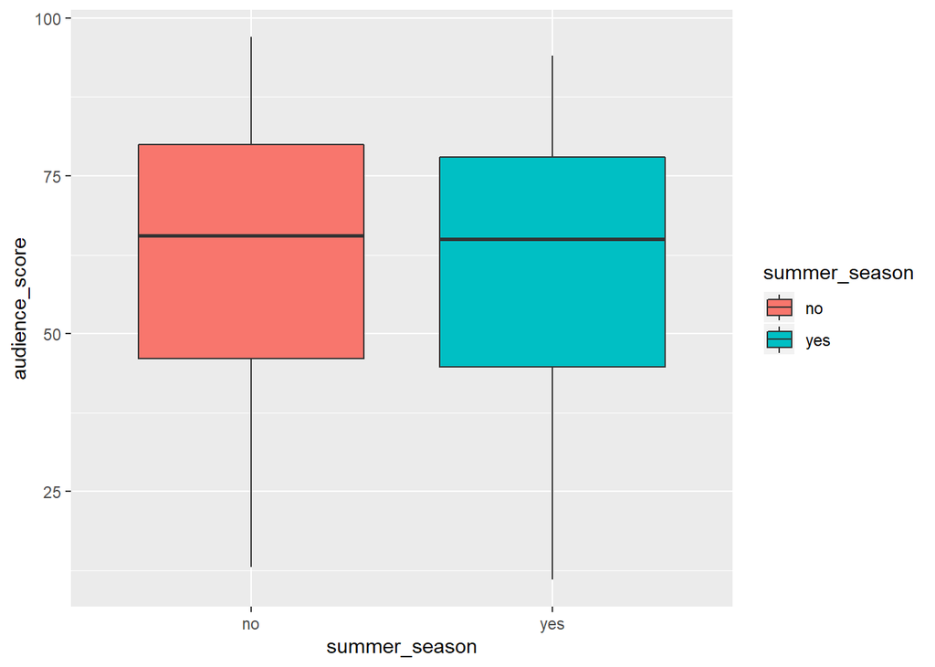

```r
#Released in Summer Vs Audience Score
ggplot(moviedata, aes(x = summer_season, y=audience_score, fill=summer_season))+ geom_boxplot()
```

The boxplots are quite different for different levels of some variables. For instance, almost the entire plot of audience_score of feature films is lower than the plot for other genres, implying that this variable could potentially be a significant predictor. On the other hand, the plots do not show much difference in audience_scores for the variables summer_season, oscar_season and mpaa_rating_R.

## Part 4: Modeling

In this section, we will be building a multiple linear regression model with audience_score as the response variable. The full model for audience score will include the variables feature_film, drama, runtime, mpaa_rating_R, thtr_rel_year, oscar_season, summer_season, imdb_rating, imdb_num_votes, critics_score, best_pic_nom, best_pic_win, best_actor_win, best_actress_win, best_dir_win and top200_box.

### Model Fit

We will use Bayesian Model Averaging (BMA) to find the best model as it allows us to average multiple models to find the appropriate coefficients and predictions from new data. We will use BIC as prior with uniform distributions for the modelpriors.

```r
#Fit Model
modelbma <- bas.lm(audience_score ~ ., data = moviedata, prior = "BIC", modelprior = uniform())
modelbma
```

```
##
## Call:
## bas.lm(formula = audience_score ~ ., data = moviedata, prior = "BIC",
##     modelprior = uniform())
##
##
##  Marginal Posterior Inclusion Probabilities:
##           Intercept      feature_filmyes             dramayes
##             1.00000              0.06537              0.04320
##             runtime     mpaa_rating_Ryes        thtr_rel_year
##             0.46971              0.19984              0.09069
##     oscar_seasonyes     summer_seasonyes          imdb_rating
##             0.07506              0.08042              1.00000
##      imdb_num_votes        critics_score      best_pic_nomyes
##             0.05774              0.88855              0.13119
##     best_pic_winyes    best_actor_winyes  best_actress_winyes
##             0.03985              0.14435              0.14128
##     best_dir_winyes        top200_boxyes
##             0.06694              0.04762
```

The output above shows the posterior inclusion probabilities of the explanatory variables. We see that imdb_rating has the highest posterior probability of being included in the model, followed by critics_score and runtime. We’ll now look at a summary of the BMA process.

```r
summary(modelbma)
```

```
##                     P(B != 0 | Y)    model 1       model 2       model 3
## Intercept              1.00000000     1.0000     1.0000000     1.0000000
## feature_filmyes        0.06536947     0.0000     0.0000000     0.0000000
## dramayes               0.04319833     0.0000     0.0000000     0.0000000
## runtime                0.46971477     1.0000     0.0000000     0.0000000
## mpaa_rating_Ryes       0.19984016     0.0000     0.0000000     0.0000000
## thtr_rel_year          0.09068970     0.0000     0.0000000     0.0000000
## oscar_seasonyes        0.07505684     0.0000     0.0000000     0.0000000
## summer_seasonyes       0.08042023     0.0000     0.0000000     0.0000000
## imdb_rating            1.00000000     1.0000     1.0000000     1.0000000
## imdb_num_votes         0.05773502     0.0000     0.0000000     0.0000000
## critics_score          0.88855056     1.0000     1.0000000     1.0000000
## best_pic_nomyes        0.13119140     0.0000     0.0000000     0.0000000
## best_pic_winyes        0.03984766     0.0000     0.0000000     0.0000000
## best_actor_winyes      0.14434896     0.0000     0.0000000     1.0000000
## best_actress_winyes    0.14128087     0.0000     0.0000000     0.0000000
## best_dir_winyes        0.06693898     0.0000     0.0000000     0.0000000
## top200_boxyes          0.04762234     0.0000     0.0000000     0.0000000
## BF                             NA     1.0000     0.9968489     0.2543185
## PostProbs                      NA     0.1297     0.1293000     0.0330000
## R2                             NA     0.7549     0.7525000     0.7539000
## dim                            NA     4.0000     3.0000000     4.0000000
## logmarg                        NA -3615.2791 -3615.2822108 -3616.6482224
##                           model 4       model 5
## Intercept               1.0000000     1.0000000
## feature_filmyes         0.0000000     0.0000000
## dramayes                0.0000000     0.0000000
## runtime                 0.0000000     1.0000000
## mpaa_rating_Ryes        1.0000000     1.0000000
## thtr_rel_year           0.0000000     0.0000000
## oscar_seasonyes         0.0000000     0.0000000
## summer_seasonyes        0.0000000     0.0000000
## imdb_rating             1.0000000     1.0000000
## imdb_num_votes          0.0000000     0.0000000
## critics_score           1.0000000     1.0000000
## best_pic_nomyes         0.0000000     0.0000000
## best_pic_winyes         0.0000000     0.0000000
## best_actor_winyes       0.0000000     0.0000000
## best_actress_winyes     0.0000000     0.0000000
## best_dir_winyes         0.0000000     0.0000000
## top200_boxyes           0.0000000     0.0000000
## BF                      0.2521327     0.2391994
## PostProbs               0.0327000     0.0310000
## R2                      0.7539000     0.7563000
## dim                     4.0000000     5.0000000
## logmarg             -3616.6568544 -3616.7095127
```

The above summary shows the most probable models. Model 1 consisting of run_time, imdb_rating and critics_score along with the Intercept is the most likely model with a posterior probability of 0.1297. Although this number doesn’t seem so high, it is significantly higher than the prior probability of 0.5^16 assigned to it. Model 2 closesly follows behind with a posterior probability of 0.1293 and includes the variables imdb_rating and critics_score along with the intercept.

### Model Coefficients

Let us first retrieve and plot the posterior distributions for the coefficients of predictors in the model.

```r
coeff_mod <- coefficients(modelbma)
coeff_mod$namesx
```

```
##  [1] "Intercept"           "feature_filmyes"     "dramayes"
##  [4] "runtime"             "mpaa_rating_Ryes"    "thtr_rel_year"
##  [7] "oscar_seasonyes"     "summer_seasonyes"    "imdb_rating"
## [10] "imdb_num_votes"      "critics_score"       "best_pic_nomyes"
## [13] "best_pic_winyes"     "best_actor_winyes"   "best_actress_winyes"
## [16] "best_dir_winyes"     "top200_boxyes"
```

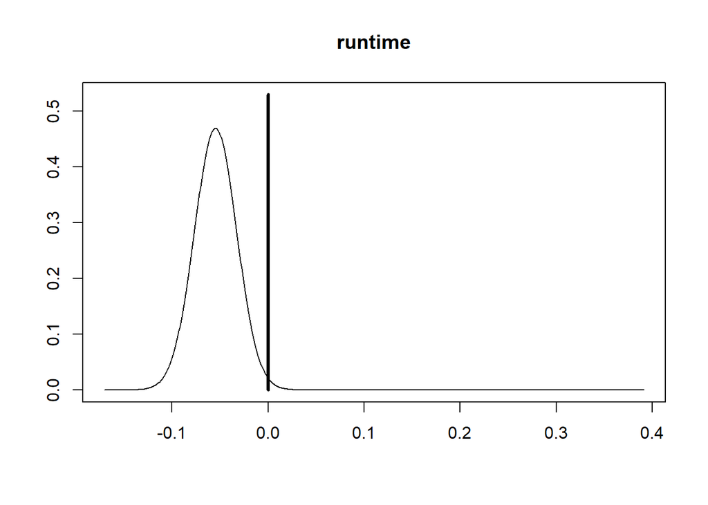

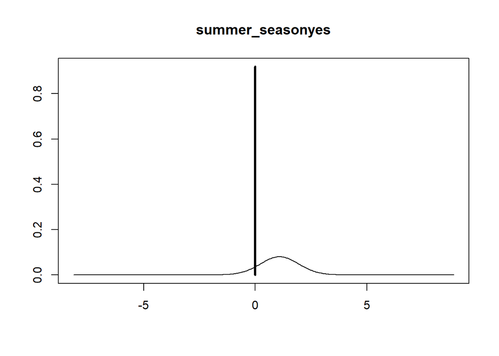

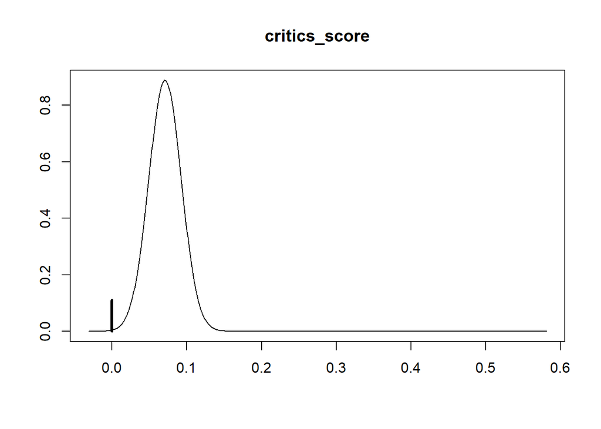

```r
plot(coeff_mod, subset = c(4,8,11), ask=FALSE)
```

```r
confint(coeff_mod)
```

```
##                              2.5%        97.5%          beta
## Intercept            6.156288e+01 6.311417e+01  6.234769e+01
## feature_filmyes     -1.268332e+00 2.439535e-02 -1.046908e-01
## dramayes             0.000000e+00 0.000000e+00  1.604413e-02
## runtime             -8.293044e-02 0.000000e+00 -2.567772e-02
## mpaa_rating_Ryes    -2.118161e+00 0.000000e+00 -3.036174e-01
## thtr_rel_year       -5.279254e-02 0.000000e+00 -4.532635e-03
## oscar_seasonyes     -8.225878e-01 3.310990e-03 -8.034940e-02
## summer_seasonyes     0.000000e+00 1.038232e+00  8.704545e-02
## imdb_rating          1.365391e+01 1.650628e+01  1.498203e+01
## imdb_num_votes      -1.254363e-07 1.433706e-06  2.080713e-07
## critics_score        0.000000e+00 1.053224e-01  6.296648e-02
## best_pic_nomyes     -5.978590e-03 4.910796e+00  5.068035e-01
## best_pic_winyes      0.000000e+00 0.000000e+00 -8.502836e-03
## best_actor_winyes   -2.627151e+00 5.046753e-04 -2.876695e-01
## best_actress_winyes -2.820014e+00 6.657066e-03 -3.088382e-01
## best_dir_winyes     -1.359051e+00 1.004616e-02 -1.195011e-01
## top200_boxyes        0.000000e+00 4.143728e-02  8.648185e-02
## attr(,"Probability")
## [1] 0.95
## attr(,"class")
## [1] "confint.bas"
```

### Model Diagnostics

We will now create some diagnostic plots.

**Constant Variability of Residuals**

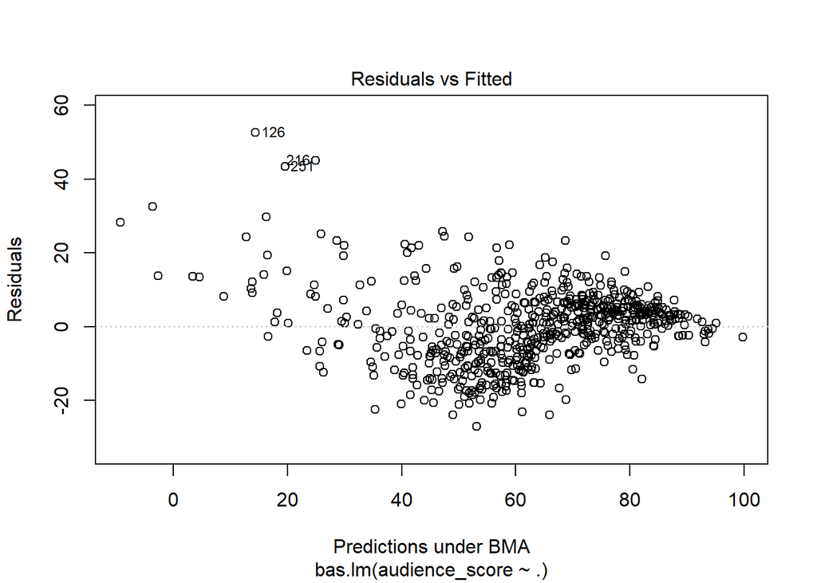

```r
#Residuals Vs Fitted
plot(modelbma, which = 1, add.smooth = F)
```

The graph shows the residuals plotted against predicted or fitted values. We see that although the plot shows mostly random scatter, there does seem to be some relationship between fitted and residual values. The residuals are less scattered for higher predicted values (>70) and more scattered for predictions less than 40. This suggests that the model is less accurate when the predictions are less than 40.

**Cumulative Probability of Models**

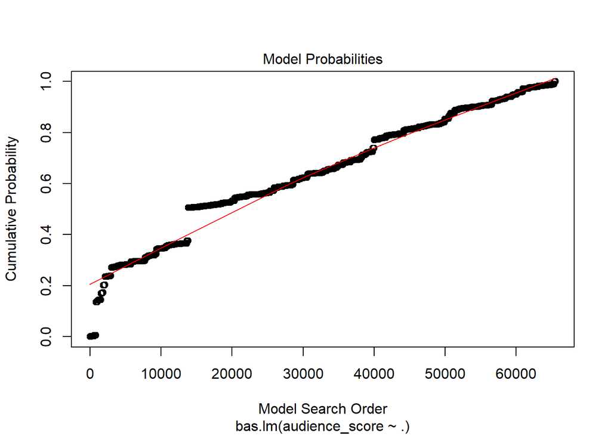

```r
#Cumulative Probability vs Model Search Order
plot(modelbma, which = 2, add.smooth = T)
```

The plot of cumulative probability and model search order looks mostly linear with 2 jumps in between. This implies that each model has something small to add to the model fit.

**Model Complexity and Probability**

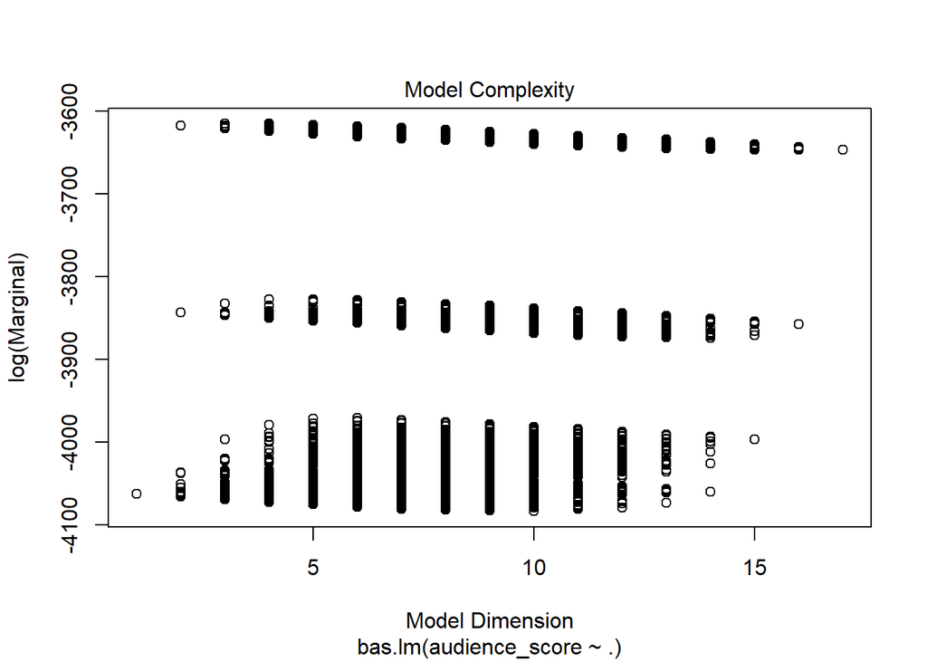

```r
#Log(Marginal Probabilities) for diff Model Dimensions
plot(modelbma, which = 3)
```

This plot shows the marginal posterior probabilities of models with different dimensions. We see that those with the highest probabilities are those with 5 or less predictors. Our most likely model from earlier fits this description as it only has 3 predictors.

**Marginal Inclusion Probabilities**

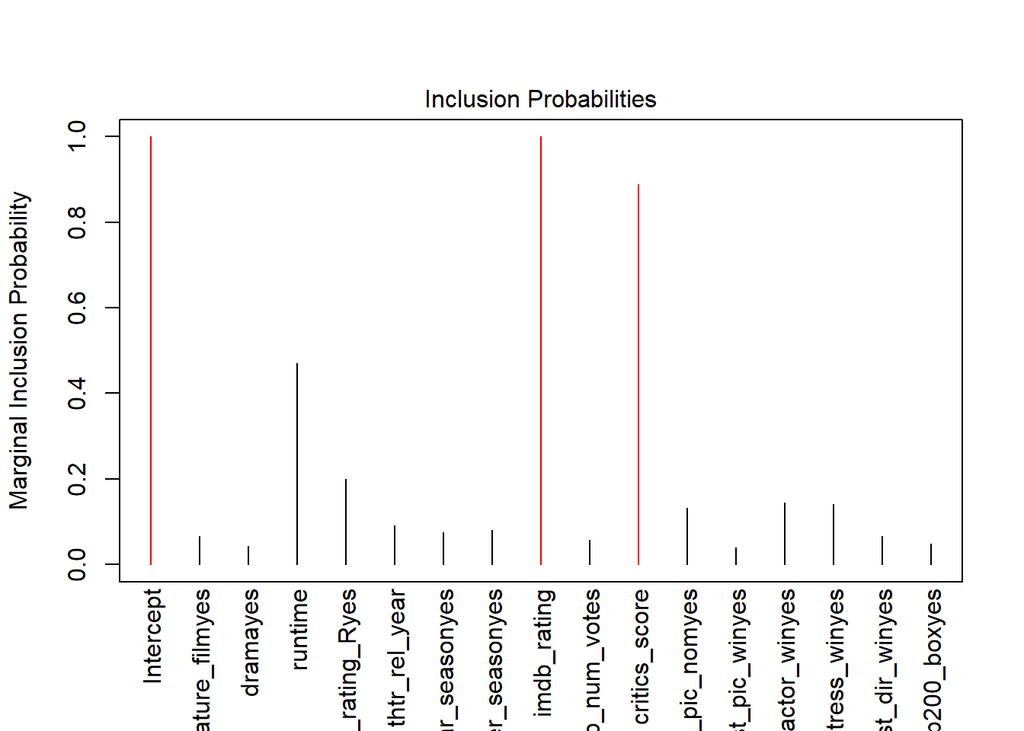

```r
#Marginal Inclusion Probabilities of predictors
plot(modelbma, which = 4, sub="")
```

This plot shows the marginal inclusion probabilities of the different predictors. imdb_rating, critics_Score and runtime have the highest inclusion probabilities and hence are included in our most likely model.

**Predictors included in different models**

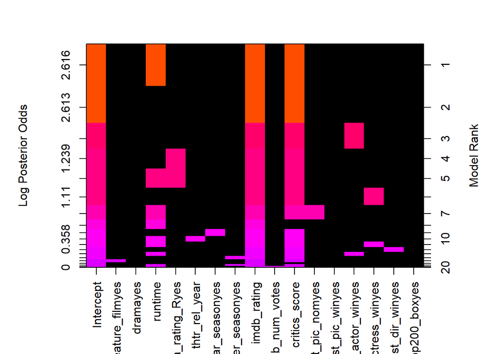

```r
#Model Rank and predictors
image(modelbma)
```

The image above shows the predictors included in the top 20 models and the odds of these models. The red spaces show highly likely (and highly ranked) models, with the purple spaces showing less likely models. The black spaces show that the predictors not included in each model. We see that imdb_rating and critics_score are included in all top models with the highest ranks.

## Part 5: Prediction

We are now ready to predict the audience score for a movie that is not included in our dataset. The movie to be predicted is “The Little Prince”, released in August 2016. We have extracted the required data from [Rotten Tomatoes](https://www.rottentomatoes.com/m/the_little_prince_2016) and [IMDB](https://www.imdb.com/title/tt1754656/?ref_=nv_sr_1?ref_=nv_sr_1). We’ll now predict a 95% prediction interval with our model. This means that if repeated samples were taken, then 95% of the samples that contain the true parameter would be between our 95% prediction interval.

```r
predict_movie <- data.frame(feature_film = "no", drama = "yes",runtime = 106,
                            mpaa_rating_R = "no", thtr_rel_year = 2016,
                            oscar_season = "no", summer_season = "yes", imdb_rating = 7.7,
                            imdb_num_votes = 51012, critics_score = 93,
                            best_pic_nom = "no", best_pic_win = "no",
                            best_actor_win = "no", best_actress_win = "no",
                            best_dir_win = "no", top200_box = "no")

#Best Predictive Model Prediction
BPM_pred <- predict(modelbma, predict_movie, estimator = "BPM", se.fit=TRUE)
confint(BPM_pred)
```

```
##          2.5%    97.5%     pred
## [1,] 63.19339 102.7966 82.99498
## attr(,"Probability")
## [1] 0.95
## attr(,"class")
## [1] "confint.bas"
```

```r
#Highest Probability Model Prediction
HPM_pred <- predict(modelbma, predict_movie, estimator = "HPM", se.fit=TRUE)
confint(HPM_pred)
```

```
##          2.5%    97.5%     pred
## [1,] 63.17175 102.6855 82.92864
## attr(,"Probability")
## [1] 0.95
## attr(,"class")
## [1] "confint.bas"
```

```r
#Median Probability Model Prediction
MPM_pred <- predict(modelbma, predict_movie, estimator = "MPM", se.fit=TRUE)
confint(MPM_pred)
```

```
##         2.5%    97.5%     pred
## [1,] 62.8198 102.4979 82.65885
## attr(,"Probability")
## [1] 0.95
## attr(,"class")
## [1] "confint.bas"
```

The 95% prediction interval based on the best predictive model is (63.19, 102.80) with the mean value 83%. The actual rating that “The Little Prince” received on Rotten Tomatoes was 84%. Hence, our prediction based on the Best Predictive Model (BPM) seems to be working alright.

The predictions based on the Highest Probability Model: 95% interval (63.17, 102.68) with mean 82.92% and predictions from Median Probability Model: 95% interval (62.82, 102.50) with mean 82.66% are also not that far off from the actual audience_score of 84%.

## Part 6: Conclusion

We have now built a multiple linear regression model that predicts the audience scores on Rotten Tomatoes using a few factors such as runtime, critics score and imdb ratings. Using Bayesian model average many models can be constructed to perform better predictions. The proposed linear model shows quite an accurate prediction rate.

It may be useful to create the initial priors with the opinion of an expert movie critic instead of the reference priors used here and thus create a better Bayesian prediction model. It is also seen that not all of the factors included in the model are intrinsic to the movie but some are extrinsic as well. This is a limitation because we won’t be able to predict the audience scores with this model before the movie comes out since we won’t know IMDB ratings and critics scores until after the movie is released. So although it’s pretty accurate, it might not be as accurate if the extrinsic variables were dropped from the model.